# IODS course project

# Chapter 5 - Dimensionality reduction techniques

## Exploring the dataset

```r
# Loading packages.
library(dplyr)
library(MASS)
library(tidyr)
library(corrplot)
library(ggplot2)
library(GGally)

# Loading the dataset.
human <- read.csv("data/human.csv")

# Exploring structure and dimensions.
str(human)
```

```
## 'data.frame':    155 obs. of  8 variables:
##  $ Edu2.FM  : num  1.007 0.997 0.983 0.989 0.969 ...
##  $ Labo.FM  : num  0.891 0.819 0.825 0.884 0.829 ...
##  $ Edu.Exp  : num  17.5 20.2 15.8 18.7 17.9 16.5 18.6 16.5 15.9 19.2 ...
##  $ Life.Exp : num  81.6 82.4 83 80.2 81.6 80.9 80.9 79.1 82 81.8 ...
##  $ GNI      : num  65 42.3 56.4 44 45.4 ...
##  $ Mat.Mor  : int  4 6 6 5 6 7 9 28 11 8 ...
##  $ Ado.Birth: num  7.8 12.1 1.9 5.1 6.2 3.8 8.2 31 14.5 25.3 ...
##  $ Parli.F  : num  39.6 30.5 28.5 38 36.9 36.9 19.9 19.4 28.2 31.4 ...
```

```r
dim(human)
```

```
## [1] 155   8
```

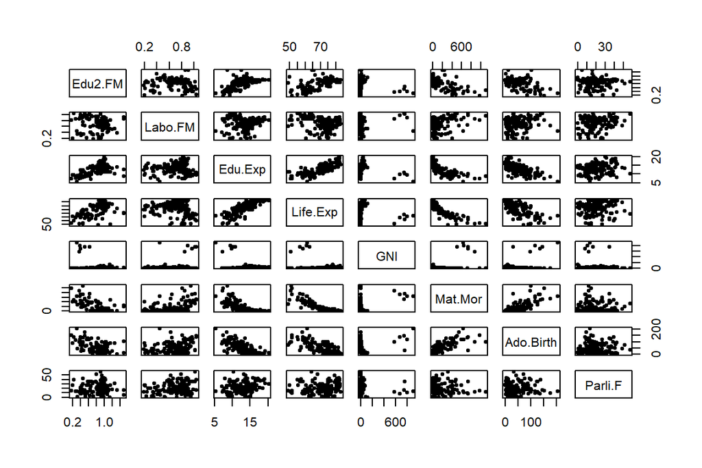

```r
# Graphical overview of the data.
pairs(human, pch = 20)
```

```r
summary(human)
```

```
##     Edu2.FM          Labo.FM          Edu.Exp         Life.Exp
##  Min.   :0.1717   Min.   :0.1857   Min.   : 5.40   Min.   :49.00
##  1st Qu.:0.7264   1st Qu.:0.5984   1st Qu.:11.25   1st Qu.:66.30
##  Median :0.9375   Median :0.7535   Median :13.50   Median :74.20
##  Mean   :0.8529   Mean   :0.7074   Mean   :13.18   Mean   :71.65
##  3rd Qu.:0.9968   3rd Qu.:0.8535   3rd Qu.:15.20   3rd Qu.:77.25
##  Max.   :1.4967   Max.   :1.0380   Max.   :20.20   Max.   :83.50
##       GNI             Mat.Mor         Ado.Birth         Parli.F
##  Min.   :  1.123   Min.   :   1.0   Min.   :  0.60   Min.   : 0.00
##  1st Qu.:  5.275   1st Qu.:  11.5   1st Qu.: 12.65   1st Qu.:12.40
##  Median : 13.054   Median :  49.0   Median : 33.60   Median :19.30
##  Mean   : 46.496   Mean   : 149.1   Mean   : 47.16   Mean   :20.91
##  3rd Qu.: 27.256   3rd Qu.: 190.0   3rd Qu.: 71.95   3rd Qu.:27.95
##  Max.   :908.000   Max.   :1100.0   Max.   :204.80   Max.   :57.50
```

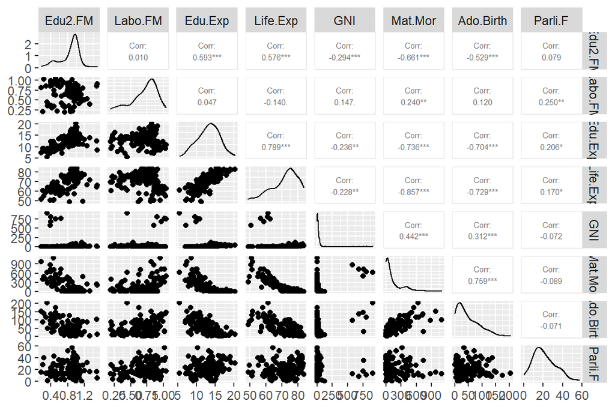

```r
# Plot correlation between variables.
p <- ggpairs(human, upper = list(continuous = wrap("cor",size=2)))
p
```

```r
# Create the correlation matrix and plot it.
cor_matrix <- round(cor(human),digits=5)
cor_matrix
```

```
##            Edu2.FM  Labo.FM  Edu.Exp Life.Exp      GNI  Mat.Mor Ado.Birth
## Edu2.FM    1.00000  0.00956  0.59325  0.57603 -0.29402 -0.66093  -0.52942
## Labo.FM    0.00956  1.00000  0.04732 -0.14001  0.14665  0.24046   0.12016
## Edu.Exp    0.59325  0.04732  1.00000  0.78944 -0.23597 -0.73570  -0.70356
## Life.Exp   0.57603 -0.14001  0.78944  1.00000 -0.22772 -0.85717  -0.72918
## GNI       -0.29402  0.14665 -0.23597 -0.22772  1.00000  0.44169   0.31238
## Mat.Mor   -0.66093  0.24046 -0.73570 -0.85717  0.44169  1.00000   0.75866
## Ado.Birth -0.52942  0.12016 -0.70356 -0.72918  0.31238  0.75866   1.00000
## Parli.F    0.07864  0.25023  0.20608  0.17009 -0.07192 -0.08944  -0.07088
##            Parli.F
## Edu2.FM    0.07864
## Labo.FM    0.25023
## Edu.Exp    0.20608
## Life.Exp   0.17009
## GNI       -0.07192
## Mat.Mor   -0.08944
## Ado.Birth -0.07088
## Parli.F    1.00000
```

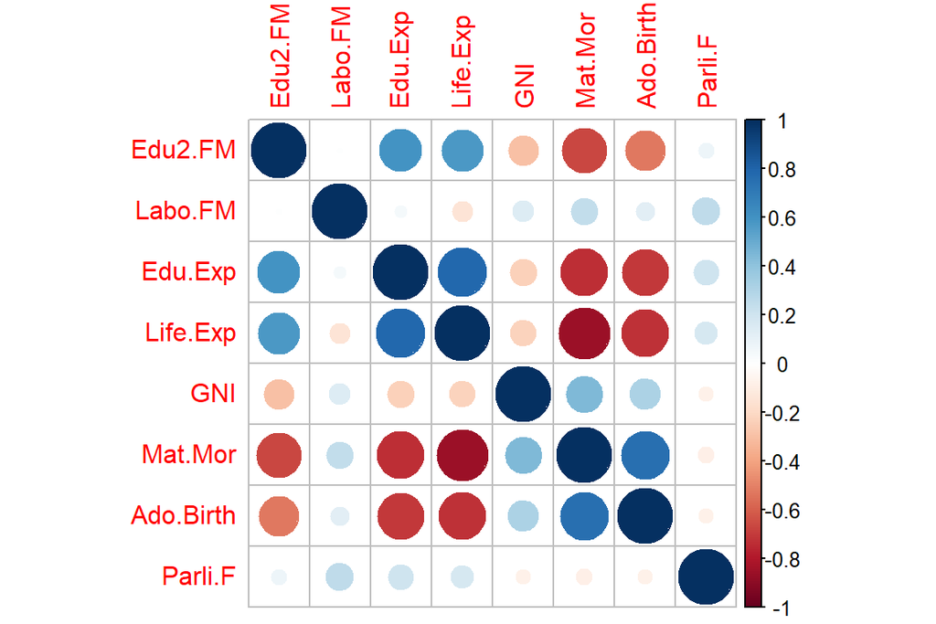

```r
corrplot(cor_matrix, method="circle")
```

## Principal component analysis (PCA)

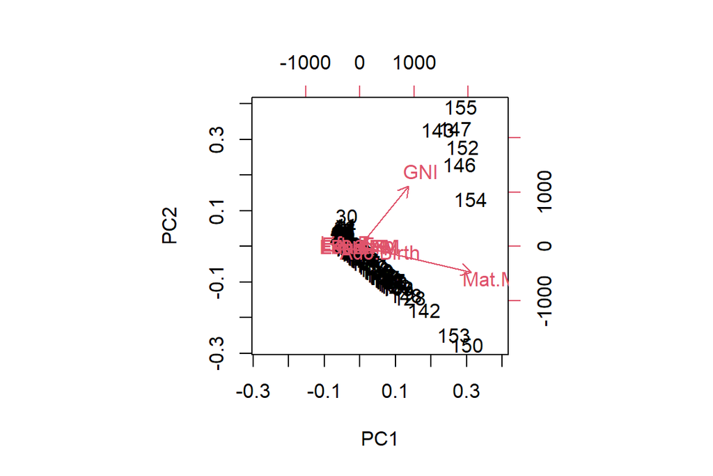

```r
# Performing PCA with raw human data
pca_human <- prcomp(human)

# Drawing a biplot of the principal component representation and the original variables.
biplot(pca_human, choices = 1:2)
```

## PCA with standardized variables

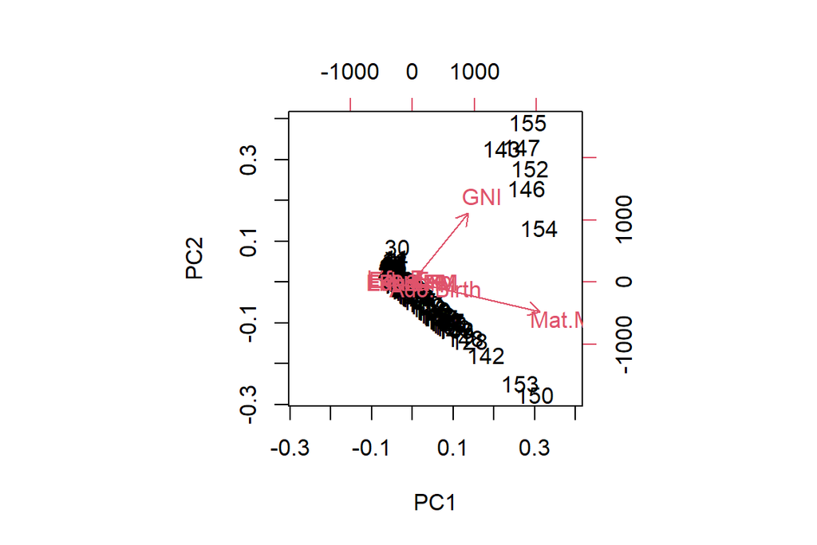

```r
# Standardizing the data.
human_std <- scale(human)

# Performing the PCA
pca_human_std <- prcomp(human_std)

# Drawing the biplot
biplot(pca_human, choices = 1:2)
```

# Chapter 6 - Analysis of longitudial data

# Part 1

## Reading the files and checking their contents

```r
# Load required packages.
library(dplyr)
library(lme4)
```

```r
library(ggplot2)
library(tidyr)

# Reading data in.
bprs_long <- read.csv("data/bprs_long.csv")
rats_long <- read.csv("data/rats_long.csv")

# Just for measure, changing the variables to factor format and sorting by week / Time.
bprs_long$treatment <- factor(bprs_long$treatment)
bprs_long$subject <- factor(bprs_long$subject)

bprs_long <- arrange(bprs_long, week)

rats_long$Group <- factor(rats_long$Group)
rats_long$ID <- factor(rats_long$ID)

rats_long <- arrange(rats_long, Time)
```

## Working with the RATS dataset

```r
# Check colnames, dimensions and structure
colnames(rats_long)
```

```
## [1] "ID"     "Group"  "Time"   "weight"
```

```r
dim(rats_long)
```

```
## [1] 176   4
```

```r
str(rats_long)
```

```
## 'data.frame':    176 obs. of  4 variables:
##  $ ID    : Factor w/ 16 levels "1","2","3","4",..: 1 2 3 4 5 6 7 8 9 10 ...
##  $ Group : Factor w/ 3 levels "1","2","3": 1 1 1 1 1 1 1 1 2 2 ...
##  $ Time  : int  1 1 1 1 1 1 1 1 1 1 ...
##  $ weight: int  240 225 245 260 255 260 275 245 410 405 ...
```

The rats dataset (long format) contains The variables ID, Group, Time and weight.  
It has 176 rows and 4 columns.  
ID and Group variables are factor types, Time and weight integers.

## Plotting the data

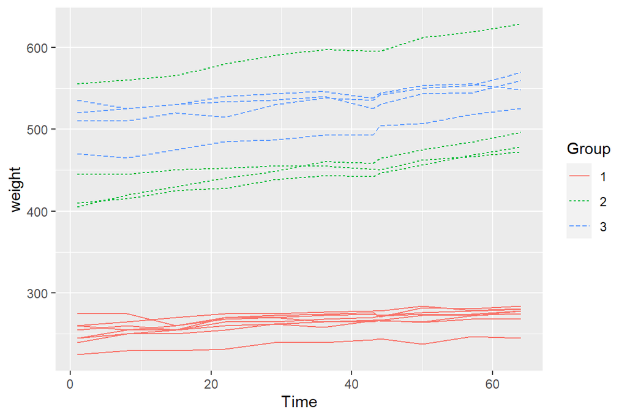

```r
# Drawing the plot.

ggplot(rats_long, aes(x = Time, y = weight, group = ID)) +
  geom_line(aes(linetype = Group, colour = Group)) +
  scale_y_continuous(limits = c(min(rats_long$weight), max(rats_long$weight)))
```

```r
glimpse(rats_long)
```

```
## Rows: 176
## Columns: 4
## $ ID     <fct> 1, 2, 3, 4, 5, 6, 7, 8, 9, 10, 11, 12, 13, 14, 15, 16, 1, 2, 3,…
## $ Group  <fct> 1, 1, 1, 1, 1, 1, 1, 1, 2, 2, 2, 2, 3, 3, 3, 3, 1, 1, 1, 1, 1, …
## $ Time   <int> 1, 1, 1, 1, 1, 1, 1, 1, 1, 1, 1, 1, 1, 1, 1, 1, 8, 8, 8, 8, 8, …
## $ weight <int> 240, 225, 245, 260, 255, 260, 275, 245, 410, 405, 445, 555, 470…
```

```r
# Standardise the variable weight.
rats_std <- rats_long %>%
  group_by(Time) %>%
    mutate(stdweight = (weight - mean(weight))/sd(weight)) %>%
  ungroup()

# Glimpse the data
glimpse(rats_std)
```

```
## Rows: 176
## Columns: 5
## $ ID        <fct> 1, 2, 3, 4, 5, 6, 7, 8, 9, 10, 11, 12, 13, 14, 15, 16, 1, 2,…
## $ Group     <fct> 1, 1, 1, 1, 1, 1, 1, 1, 2, 2, 2, 2, 3, 3, 3, 3, 1, 1, 1, 1, …
## $ Time      <int> 1, 1, 1, 1, 1, 1, 1, 1, 1, 1, 1, 1, 1, 1, 1, 1, 8, 8, 8, 8, …
## $ weight    <int> 240, 225, 245, 260, 255, 260, 275, 245, 410, 405, 445, 555, …
## $ stdweight <dbl> -1.0011429, -1.1203857, -0.9613953, -0.8421525, -0.8819001, …
```

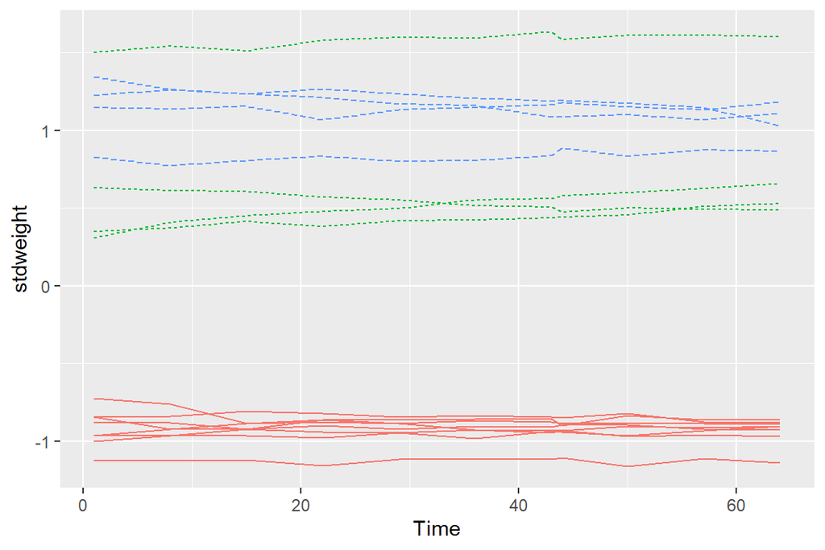

```r
# Plot again with the standardised bprs

ggplot(rats_std, aes(x = Time, y = stdweight, group = ID)) +
  geom_line(aes(linetype = Group, colour = Group)) +
  theme(legend.position = "none") +
  scale_y_continuous(limits = c(min(rats_std$stdweight), max(rats_std$stdweight)))
```

We can see that the rats in groups 2 and 3 gain more weight as time passes, and have more weight in the beginning than group 1 rats. However, and even more clearly after the standardization, we can see that the group 1 rats do not gain as much weight as the other two.

## Summary graphs

```r
# Work with the exercise in this chunk, step-by-step. Fix the R code!
# BPRSL is available

# Number of subjects (per group):

sum(rats_std$Group == 1)
```

```
## [1] 88
```

```r
sum(rats_std$Group == 2)
```

```
## [1] 44
```

```r
sum(rats_std$Group == 3)
```

```
## [1] 44
```

```r
n = 44

# Summary data with mean and standard error of bprs by treatment and week
rats_std <- rats_std %>%
  group_by(Group, Time) %>%
  summarise( mean = mean(weight), se =  sd(weight)/sqrt(n)) %>%
  ungroup()
# Glimpse the data
glimpse(rats_std)
```

```
## Rows: 33
## Columns: 4
## $ Group <fct> 1, 1, 1, 1, 1, 1, 1, 1, 1, 1, 1, 2, 2, 2, 2, 2, 2, 2, 2, 2, 2, 2…
## $ Time  <int> 1, 8, 15, 22, 29, 36, 43, 44, 50, 57, 64, 1, 8, 15, 22, 29, 36, …
## $ mean  <dbl> 250.625, 255.000, 254.375, 261.875, 264.625, 265.000, 267.375, 2…
## $ se    <dbl> 2.294739, 1.973855, 1.730058, 2.050400, 1.666978, 1.776470, 1.65…
```

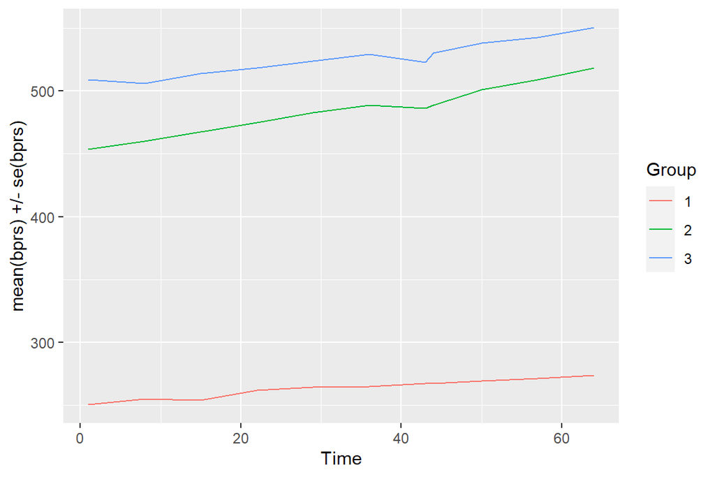

```r
# Plot the mean profiles
library(ggplot2)
ggplot(rats_std, aes(x = Time, y = mean, col = Group)) +
  geom_line() +
  #geom_errorbar(aes(ymin=mean-se, ymax=mean+se, linetype="1"), width=0.3) +
  scale_y_continuous(name = "mean(bprs) +/- se(bprs)")
```

From the mean profile plots, we can see that the rats do gain weight over time. The rate is faster for groups 2 and 3 as previously observed. There is also an interesting dip in weights for the groups 2 and 3 at around 37-42 days which is not true for group 1.

## Finding the outliers

```r
# Creating a summary data with grouping Group and ID with weight mean as summary variable.
rats_summary <- rats_long %>%
  filter(Time > 1) %>%
  group_by(Group, ID) %>%
  summarise( mean=mean(weight)) %>%
  ungroup()
# Checking the data with glimpse.
glimpse(rats_summary)
```

```
## Rows: 16
## Columns: 3
## $ Group <fct> 1, 1, 1, 1, 1, 1, 1, 1, 2, 2, 2, 2, 3, 3, 3, 3
## $ ID    <fct> 1, 2, 3, 4, 5, 6, 7, 8, 9, 10, 11, 12, 13, 14, 15, 16
## $ mean  <dbl> 263.2, 238.9, 261.7, 267.2, 270.9, 276.2, 274.6, 267.5, 443.9, 4…
```

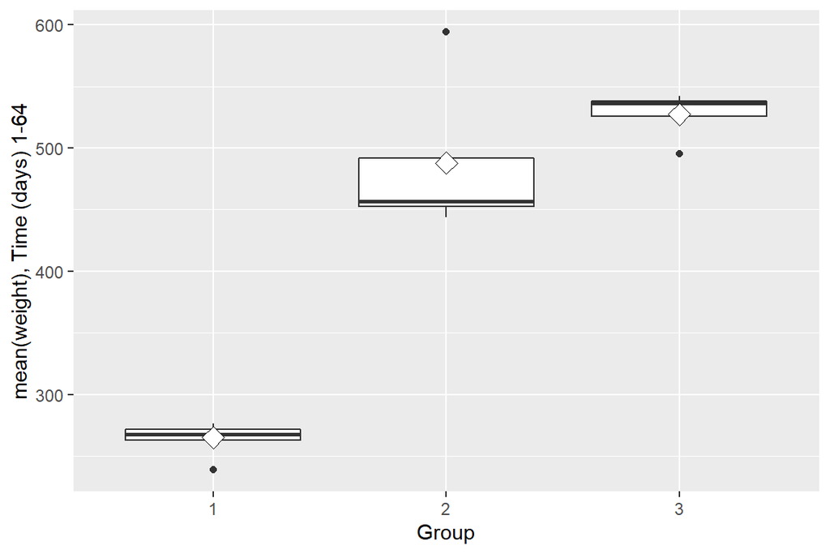

```r
# Drawing the boxplot of mean values between groups.
ggplot(rats_summary, aes(x = Group, y = mean)) +
  geom_boxplot() +
  stat_summary(fun = "mean", geom = "point", shape=23, size=4, fill = "white") +
  scale_y_continuous(name = "mean(weight), Time (days) 1-64")
```

```r
# Create a new data by filtering the outlier and adjust the ggplot code the draw the plot again with the new data

# Splitting the data by rat groups, removing the outliers for each group and combining them with rbind.
rats1 <- rats_summary[rats_summary$Group == 1,]
rats2 <- rats_summary[rats_summary$Group == 2,]
rats3 <- rats_summary[rats_summary$Group == 3,]

g1_Q1 <- quantile(rats1$mean, .25)
g1_Q3 <- quantile(rats1$mean, .75)
g1_IQR <- IQR(rats1$mean)

g2_Q1 <- quantile(rats2$mean, .25)
g2_Q3 <- quantile(rats2$mean, .75)
g2_IQR <- IQR(rats2$mean)

g3_Q1 <- quantile(rats3$mean, .25)
g3_Q3 <- quantile(rats3$mean, .75)
g3_IQR <- IQR(rats3$mean)

rats1 <- subset(rats1, rats1$mean > (g1_Q1 - 1.5*g1_IQR) & rats1$mean < (g1_Q3 + 1.5*g1_IQR))
rats2 <- subset(rats2, rats2$mean > (g2_Q1 - 1.5*g2_IQR) & rats2$mean < (g2_Q3 + 1.5*g2_IQR))
rats3 <- subset(rats3, rats3$mean > (g3_Q1 - 1.5*g3_IQR) & rats3$mean < (g3_Q3 + 1.5*g3_IQR))

glimpse(rats1)
```

```
## Rows: 7
## Columns: 3
## $ Group <fct> 1, 1, 1, 1, 1, 1, 1
## $ ID    <fct> 1, 3, 4, 5, 6, 7, 8
## $ mean  <dbl> 263.2, 261.7, 267.2, 270.9, 276.2, 274.6, 267.5
```

```r
glimpse(rats2)
```

```
## Rows: 3
## Columns: 3
## $ Group <fct> 2, 2, 2
## $ ID    <fct> 9, 10, 11
## $ mean  <dbl> 443.9, 457.5, 455.8
```

```r
glimpse(rats3)
```

```
## Rows: 3
## Columns: 3
## $ Group <fct> 3, 3, 3
## $ ID    <fct> 14, 15, 16
## $ mean  <dbl> 536.4, 542.2, 536.2
```

```r
rats_summary_out <- data.frame()
rats_summary_out <- rbind(rats_summary_out, rats1)
rats_summary_out <- rbind(rats_summary_out, rats2)
rats_summary_out <- rbind(rats_summary_out, rats3)
glimpse(rats_summary_out)
```

```
## Rows: 13
## Columns: 3
## $ Group <fct> 1, 1, 1, 1, 1, 1, 1, 2, 2, 2, 3, 3, 3
## $ ID    <fct> 1, 3, 4, 5, 6, 7, 8, 9, 10, 11, 14, 15, 16
## $ mean  <dbl> 263.2, 261.7, 267.2, 270.9, 276.2, 274.6, 267.5, 443.9, 457.5, 4…
```

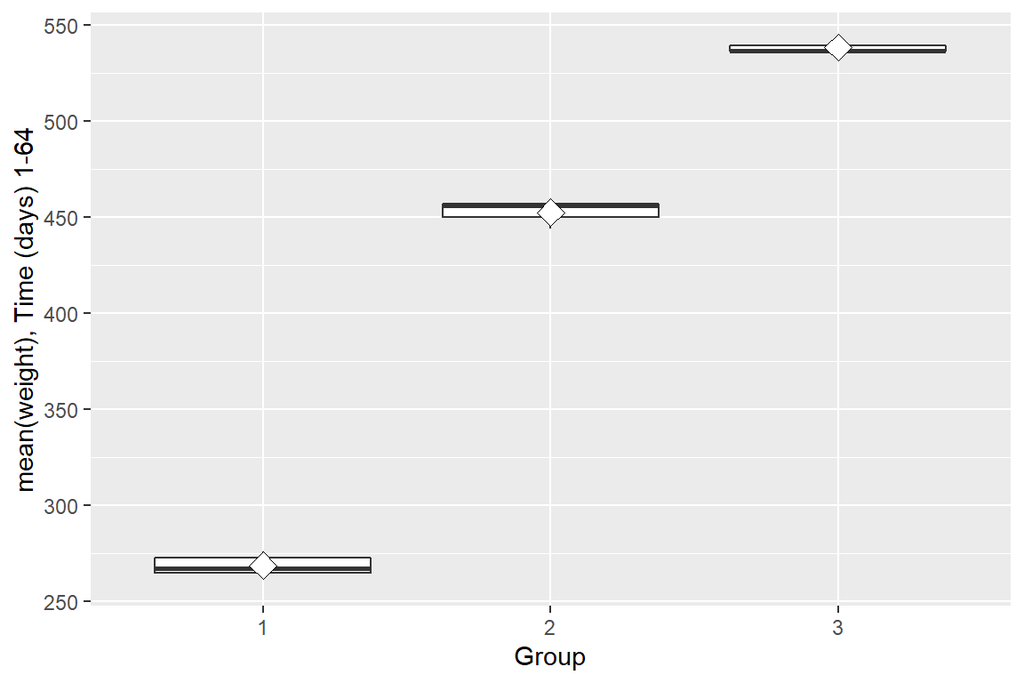

```r
ggplot(rats_summary_out, aes(x = Group, y = mean)) +
  geom_boxplot() +
  stat_summary(fun = "mean", geom = "point", shape=23, size=4, fill = "white") +
  scale_y_continuous(name = "mean(weight), Time (days) 1-64")
```

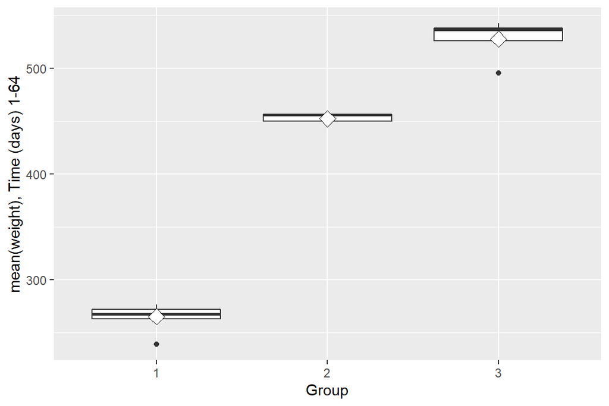

```r
# Removing only the one outlier with the filter function.
rats_summary_out <- rats_summary %>% filter(mean <550)

ggplot(rats_summary_out, aes(x = Group, y = mean)) +
  geom_boxplot() +
  stat_summary(fun = "mean", geom = "point", shape=23, size=4, fill = "white") +
  scale_y_continuous(name = "mean(weight), Time (days) 1-64")
```

As we previously saw from the data, group 1 has the lowest weight from the three groups and group 3 the highest. The weight difference between group 1 and 2-3 is quite large, so if lower weight was the goal, group 1 outperformed the rest with a large margin.

## Anova test

```r
# Creating the baseline from original data.
rats_base <- rats_long[rats_long$Time == 1,]

# Add the baseline from the original data as a new variable to the summary data
rats_summary_out <- rats_summary %>%
  mutate(baseline = rats_base$weight)
rats_summary_out
```

```
## # A tibble: 16 × 4
##    Group ID     mean baseline
##    <fct> <fct> <dbl>    <int>
##  1 1     1      263.      240
##  2 1     2      239.      225
##  3 1     3      262.      245
##  4 1     4      267.      260
##  5 1     5      271.      255
##  6 1     6      276.      260
##  7 1     7      275.      275
##  8 1     8      268.      245
##  9 2     9      444.      410
## 10 2     10     458.      405
## 11 2     11     456.      445
## 12 2     12     594       555
## 13 3     13     495.      470
## 14 3     14     536.      535
## 15 3     15     542.      520
## 16 3     16     536.      510
```

```r
# Fit the linear model with the mean as the response
fit <- lm(mean ~ baseline, data = rats_summary_out)

# Compute the analysis of variance table for the fitted model with anova()
anova(fit)
```

```
## Analysis of Variance Table
##
## Response: mean
##           Df Sum Sq Mean Sq F value    Pr(>F)
## baseline   1 253625  253625  1411.7 1.852e-15 ***
## Residuals 14   2515     180
## ---
## Signif. codes:  0 '***' 0.001 '**' 0.01 '*' 0.05 '.' 0.1 ' ' 1
```

# Part 2

## Linear mixed effects model

```r
dim(bprs_long)
```

```
## [1] 360   4
```

```r
str(bprs_long)
```

```
## 'data.frame':    360 obs. of  4 variables:
##  $ treatment: Factor w/ 2 levels "1","2": 1 1 1 1 1 1 1 1 1 1 ...
##  $ subject  : Factor w/ 20 levels "1","2","3","4",..: 1 2 3 4 5 6 7 8 9 10 ...
##  $ week     : int  0 0 0 0 0 0 0 0 0 0 ...
##  $ bprs     : int  42 58 54 55 72 48 71 30 41 57 ...
```

```r
glimpse(bprs_long)
```

```
## Rows: 360
## Columns: 4
## $ treatment <fct> 1, 1, 1, 1, 1, 1, 1, 1, 1, 1, 1, 1, 1, 1, 1, 1, 1, 1, 1, 1, …
## $ subject   <fct> 1, 2, 3, 4, 5, 6, 7, 8, 9, 10, 11, 12, 13, 14, 15, 16, 17, 1…
## $ week      <int> 0, 0, 0, 0, 0, 0, 0, 0, 0, 0, 0, 0, 0, 0, 0, 0, 0, 0, 0, 0, …
## $ bprs      <int> 42, 58, 54, 55, 72, 48, 71, 30, 41, 57, 30, 55, 36, 38, 66, …
```

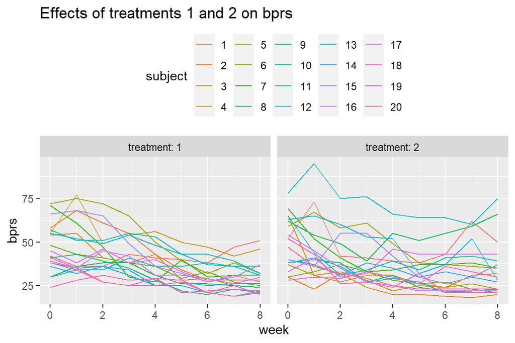

```r
ggplot(bprs_long, aes(x = week, y = bprs, col = subject)) +
  geom_line() +
  facet_grid(cols = vars(treatment),
             labeller = label_both) +
  labs(title = "Effects of treatments 1 and 2 on bprs") +
  theme(legend.position = "top")
```

At a first glance, it is quite difficult to say which treatment has better results.

## Multiple linear regression model

```r
bprs_reg <- lm(bprs ~ week + treatment, data = bprs_long)
summary(bprs_reg)
```

```
##
## Call:
## lm(formula = bprs ~ week + treatment, data = bprs_long)
##
## Residuals:
##     Min      1Q  Median      3Q     Max
## -22.454  -8.965  -3.196   7.002  50.244
##
## Coefficients:
##             Estimate Std. Error t value Pr(>|t|)
## (Intercept)  46.4539     1.3670  33.982   <2e-16 ***
## week         -2.2704     0.2524  -8.995   <2e-16 ***
## treatment2    0.5722     1.3034   0.439    0.661
## ---
## Signif. codes:  0 '***' 0.001 '**' 0.01 '*' 0.05 '.' 0.1 ' ' 1
##
## Residual standard error: 12.37 on 357 degrees of freedom
## Multiple R-squared:  0.1851, Adjusted R-squared:  0.1806
## F-statistic: 40.55 on 2 and 357 DF,  p-value: < 2.2e-16
```

## Random intercept model

```r
bprs_ref <- lmer(bprs ~ week + treatment + (1 | subject), data = bprs_long, REML = FALSE)
summary(bprs_ref)
```

```
## Linear mixed model fit by maximum likelihood  ['lmerMod']
## Formula: bprs ~ week + treatment + (1 | subject)
##    Data: bprs_long
##
##      AIC      BIC   logLik deviance df.resid
##   2748.7   2768.1  -1369.4   2738.7      355
##
## Scaled residuals:
##     Min      1Q  Median      3Q     Max
## -3.0481 -0.6749 -0.1361  0.4813  3.4855
##
## Random effects:
##  Groups   Name        Variance Std.Dev.
##  subject  (Intercept)  47.41    6.885
##  Residual             104.21   10.208
## Number of obs: 360, groups:  subject, 20
##
## Fixed effects:
##             Estimate Std. Error t value
## (Intercept)  46.4539     1.9090  24.334
## week         -2.2704     0.2084 -10.896
## treatment2    0.5722     1.0761   0.532
##
## Correlation of Fixed Effects:
##            (Intr) week
## week       -0.437
## treatment2 -0.282  0.000
```

## Random Intercept and Random Slope Model

```r
# Create a random intercept and random slope model.
bprs_ref1 <- lmer(bprs ~ week + treatment + (week | subject), data = bprs_long, REML = FALSE)

# Print a summary of the model.
summary(bprs_ref1)
```

```
## Linear mixed model fit by maximum likelihood  ['lmerMod']
## Formula: bprs ~ week + treatment + (week | subject)
##    Data: bprs_long
##
##      AIC      BIC   logLik deviance df.resid
##   2745.4   2772.6  -1365.7   2731.4      353
##
## Scaled residuals:
##     Min      1Q  Median      3Q     Max
## -2.8919 -0.6194 -0.0691  0.5531  3.7976
##
## Random effects:
##  Groups   Name        Variance Std.Dev. Corr
##  subject  (Intercept) 64.8222  8.0512
##           week         0.9609  0.9802   -0.51
##  Residual             97.4305  9.8707
## Number of obs: 360, groups:  subject, 20
##
## Fixed effects:
##             Estimate Std. Error t value
## (Intercept)  46.4539     2.1052  22.066
## week         -2.2704     0.2977  -7.626
## treatment2    0.5722     1.0405   0.550
##
## Correlation of Fixed Effects:
##            (Intr) week
## week       -0.582
## treatment2 -0.247  0.000
```

```r
# Perform an ANOVA test on the two models.
anova(bprs_ref1, bprs_ref)
```

```
## Data: bprs_long
## Models:
## bprs_ref: bprs ~ week + treatment + (1 | subject)
## bprs_ref1: bprs ~ week + treatment + (week | subject)
##           npar    AIC    BIC  logLik deviance  Chisq Df Pr(>Chisq)
## bprs_ref     5 2748.7 2768.1 -1369.4   2738.7
## bprs_ref1    7 2745.4 2772.6 -1365.7   2731.4 7.2721  2    0.02636 *
## ---
## Signif. codes:  0 '***' 0.001 '**' 0.01 '*' 0.05 '.' 0.1 ' ' 1
```

## Random Intercept and Random Slope Model with interaction

```r
# create a random intercept and random slope model with the interaction
bprs_ref2 <- lmer(bprs ~ week * treatment + (week | subject), data = bprs_long, REML = FALSE)

# print a summary of the model
summary(bprs_ref2)
```

```
## Linear mixed model fit by maximum likelihood  ['lmerMod']
## Formula: bprs ~ week * treatment + (week | subject)
##    Data: bprs_long
##
##      AIC      BIC   logLik deviance df.resid
##   2744.3   2775.4  -1364.1   2728.3      352
##
## Scaled residuals:
##     Min      1Q  Median      3Q     Max
## -3.0512 -0.6271 -0.0768  0.5288  3.9260
##
## Random effects:
##  Groups   Name        Variance Std.Dev. Corr
##  subject  (Intercept) 64.9964  8.0620
##           week         0.9687  0.9842   -0.51
##  Residual             96.4707  9.8220
## Number of obs: 360, groups:  subject, 20
##
## Fixed effects:
##                 Estimate Std. Error t value
## (Intercept)      47.8856     2.2521  21.262
## week             -2.6283     0.3589  -7.323
## treatment2       -2.2911     1.9090  -1.200
## week:treatment2   0.7158     0.4010   1.785
##
## Correlation of Fixed Effects:
##             (Intr) week   trtmn2
## week        -0.650
## treatment2  -0.424  0.469
## wek:trtmnt2  0.356 -0.559 -0.840
```

```r
# perform an ANOVA test on the two models
anova(bprs_ref2, bprs_ref1)
```

```
## Data: bprs_long
## Models:
## bprs_ref1: bprs ~ week + treatment + (week | subject)
## bprs_ref2: bprs ~ week * treatment + (week | subject)
##           npar    AIC    BIC  logLik deviance  Chisq Df Pr(>Chisq)
## bprs_ref1    7 2745.4 2772.6 -1365.7   2731.4
## bprs_ref2    8 2744.3 2775.4 -1364.1   2728.3 3.1712  1    0.07495 .
## ---
## Signif. codes:  0 '***' 0.001 '**' 0.01 '*' 0.05 '.' 0.1 ' ' 1
```

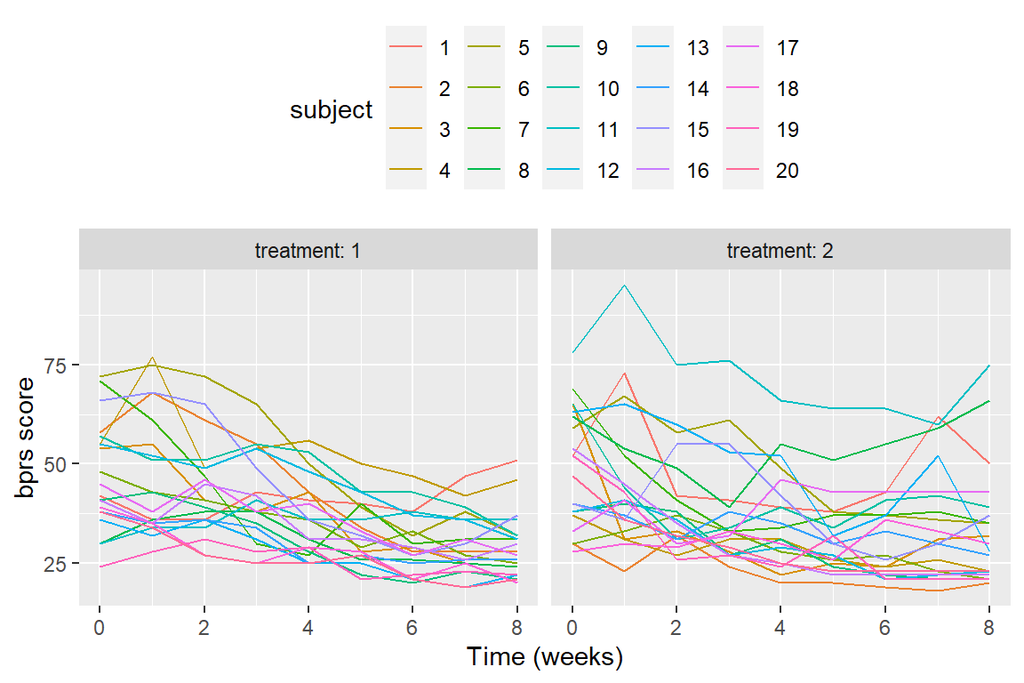

```r
# draw the plot of RATSL with the observed Weight values
ggplot(bprs_long, aes(x = week, y = bprs, colour = subject)) +
  facet_grid(cols = vars(treatment),
             labeller = label_both) +
  geom_line() +
  scale_x_continuous(name = "Time (weeks)") +
  scale_y_continuous(name = "bprs score") +
  theme(legend.position = "top")
```

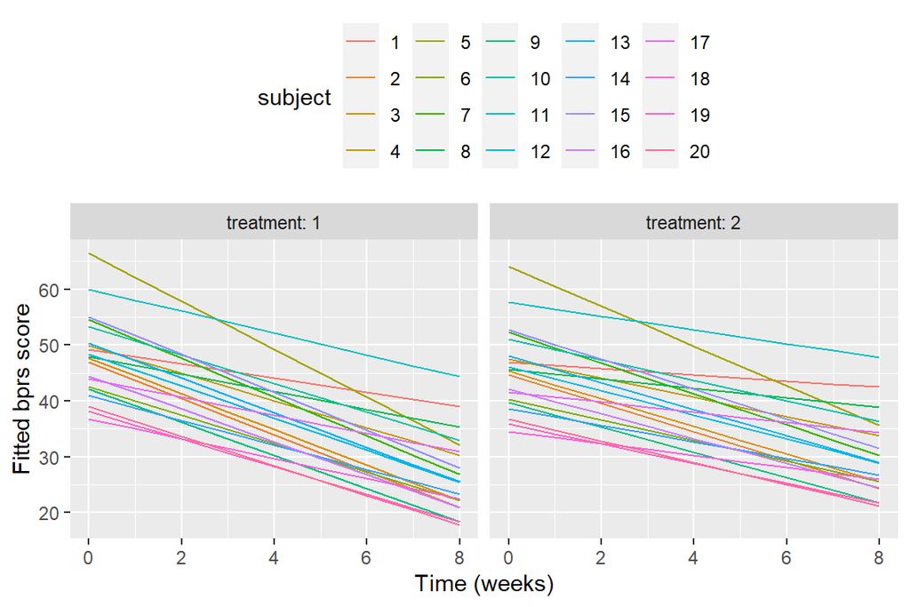

```r
# Create a vector of the fitted values
bprs_fitted <- fitted(bprs_ref2)


# Create a new column fitted to RATSL
bprs_long <- mutate(bprs_long, fitted = bprs_fitted)

# draw the plot of RATSL with the Fitted values of weight
ggplot(bprs_long, aes(x = week, y = bprs_fitted, colour = subject)) +
  facet_grid(cols = vars(treatment),
           labeller = label_both) +
  geom_line() +
  scale_x_continuous(name = "Time (weeks)") +
  scale_y_continuous(name = "Fitted bprs score") +
  theme(legend.position = "top")
```

It is really difficult to say which treatment had better results. If I had to make a quess, I would say that treatment 1 had a slightly better performance since most of the subjects seem to have a lower score in the end than the ones in treatment group 2.

All done! :)